# Risk Factor Analysis

## Outcome Variable

**Outcome Variable:** whz

## Predictor Variables

**Intervention Variable:** perdiar24

**Adjustment Set:**

- arm
- sex
- meducyrs
- hhwealth_quart
- hfoodsec
- hdlvry
- W_birthwt
- W_birthlen
- W_nrooms
- month
- brthmon
- impfloor
- impsan
- safeh20
- delta_meducyrs
- delta_hhwealth_quart
- delta_hfoodsec
- delta_hdlvry
- delta_W_birthwt
- delta_W_birthlen
- delta_W_nrooms
- delta_month
- delta_brthmon
- delta_impfloor
- delta_impsan
- delta_safeh20

## Stratifying Variables

The analysis was stratified on these variable(s):

- agecat
- studyid
- country

## Data Summary

| agecat | studyid | country | perdiar24 | n_cell | n |
| --- | --- | --- | --- | --- | --- |
| Birth | ki0047075b-MAL-ED | BANGLADESH | 0% | 18 | 241 |
| Birth | ki0047075b-MAL-ED | BANGLADESH | (0%, 5%] | 142 | 241 |
| Birth | ki0047075b-MAL-ED | BANGLADESH | >5% | 81 | 241 |
| Birth | ki0047075b-MAL-ED | BRAZIL | 0% | 105 | 183 |
| Birth | ki0047075b-MAL-ED | BRAZIL | (0%, 5%] | 76 | 183 |
| Birth | ki0047075b-MAL-ED | BRAZIL | >5% | 2 | 183 |
| Birth | ki0047075b-MAL-ED | INDIA | 0% | 12 | 203 |
| Birth | ki0047075b-MAL-ED | INDIA | (0%, 5%] | 153 | 203 |
| Birth | ki0047075b-MAL-ED | INDIA | >5% | 38 | 203 |
| Birth | ki0047075b-MAL-ED | NEPAL | 0% | 13 | 168 |
| Birth | ki0047075b-MAL-ED | NEPAL | (0%, 5%] | 101 | 168 |
| Birth | ki0047075b-MAL-ED | NEPAL | >5% | 54 | 168 |
| Birth | ki0047075b-MAL-ED | PERU | 0% | 26 | 279 |
| Birth | ki0047075b-MAL-ED | PERU | (0%, 5%] | 107 | 279 |
| Birth | ki0047075b-MAL-ED | PERU | >5% | 146 | 279 |
| Birth | ki0047075b-MAL-ED | SOUTH AFRICA | 0% | 95 | 250 |
| Birth | ki0047075b-MAL-ED | SOUTH AFRICA | (0%, 5%] | 152 | 250 |
| Birth | ki0047075b-MAL-ED | SOUTH AFRICA | >5% | 3 | 250 |
| Birth | ki0047075b-MAL-ED | TANZANIA, UNITED REPUBLIC OF | 0% | 8 | 118 |
| Birth | ki0047075b-MAL-ED | TANZANIA, UNITED REPUBLIC OF | (0%, 5%] | 86 | 118 |
| Birth | ki0047075b-MAL-ED | TANZANIA, UNITED REPUBLIC OF | >5% | 24 | 118 |
| Birth | ki1000109-EE | PAKISTAN | 0% | 0 | 1 |
| Birth | ki1000109-EE | PAKISTAN | (0%, 5%] | 1 | 1 |
| Birth | ki1000109-EE | PAKISTAN | >5% | 0 | 1 |
| Birth | ki1000109-ResPak | PAKISTAN | 0% | 0 | 5 |
| Birth | ki1000109-ResPak | PAKISTAN | (0%, 5%] | 1 | 5 |
| Birth | ki1000109-ResPak | PAKISTAN | >5% | 4 | 5 |
| Birth | ki1017093-NIH-Birth | BANGLADESH | 0% | 4 | 26 |
| Birth | ki1017093-NIH-Birth | BANGLADESH | (0%, 5%] | 8 | 26 |
| Birth | ki1017093-NIH-Birth | BANGLADESH | >5% | 14 | 26 |

[output cut: 123 more lines]

The following strata were considered:

- agecat: 24 months, studyid: ki0047075b-MAL-ED, country: BANGLADESH
- agecat: 24 months, studyid: ki0047075b-MAL-ED, country: BRAZIL
- agecat: 24 months, studyid: ki0047075b-MAL-ED, country: INDIA
- agecat: 24 months, studyid: ki0047075b-MAL-ED, country: NEPAL
- agecat: 24 months, studyid: ki0047075b-MAL-ED, country: PERU
- agecat: 24 months, studyid: ki0047075b-MAL-ED, country: SOUTH AFRICA
- agecat: 24 months, studyid: ki0047075b-MAL-ED, country: TANZANIA, UNITED REPUBLIC OF
- agecat: 24 months, studyid: ki1017093-NIH-Birth, country: BANGLADESH
- agecat: 24 months, studyid: ki1017093b-PROVIDE, country: BANGLADESH
- agecat: 24 months, studyid: ki1017093c-NIH-Crypto, country: BANGLADESH
- agecat: 24 months, studyid: ki1114097-CMIN, country: BANGLADESH
- agecat: 24 months, studyid: ki1114097-CMIN, country: GUINEA-BISSAU
- agecat: 24 months, studyid: ki1114097-CMIN, country: PERU
- agecat: 24 months, studyid: ki1114097-CONTENT, country: PERU
- agecat: 24 months, studyid: kiGH5241-JiVitA-4, country: BANGLADESH
- agecat: 6 months, studyid: ki0047075b-MAL-ED, country: BANGLADESH
- agecat: 6 months, studyid: ki0047075b-MAL-ED, country: BRAZIL
- agecat: 6 months, studyid: ki0047075b-MAL-ED, country: INDIA
- agecat: 6 months, studyid: ki0047075b-MAL-ED, country: NEPAL
- agecat: 6 months, studyid: ki0047075b-MAL-ED, country: PERU
- agecat: 6 months, studyid: ki0047075b-MAL-ED, country: SOUTH AFRICA
- agecat: 6 months, studyid: ki0047075b-MAL-ED, country: TANZANIA, UNITED REPUBLIC OF
- agecat: 6 months, studyid: ki1000109-EE, country: PAKISTAN
- agecat: 6 months, studyid: ki1000109-ResPak, country: PAKISTAN
- agecat: 6 months, studyid: ki1000304b-SAS-FoodSuppl, country: INDIA
- agecat: 6 months, studyid: ki1017093-NIH-Birth, country: BANGLADESH
- agecat: 6 months, studyid: ki1017093b-PROVIDE, country: BANGLADESH
- agecat: 6 months, studyid: ki1017093c-NIH-Crypto, country: BANGLADESH
- agecat: 6 months, studyid: ki1112895-Guatemala BSC, country: GUATEMALA
- agecat: 6 months, studyid: ki1114097-CMIN, country: BANGLADESH
- agecat: 6 months, studyid: ki1114097-CMIN, country: BRAZIL
- agecat: 6 months, studyid: ki1114097-CMIN, country: GUINEA-BISSAU
- agecat: 6 months, studyid: ki1114097-CMIN, country: PERU
- agecat: 6 months, studyid: ki1114097-CONTENT, country: PERU
- agecat: 6 months, studyid: kiGH5241-JiVitA-4, country: BANGLADESH
- agecat: Birth, studyid: ki0047075b-MAL-ED, country: BANGLADESH
- agecat: Birth, studyid: ki0047075b-MAL-ED, country: BRAZIL
- agecat: Birth, studyid: ki0047075b-MAL-ED, country: INDIA
- agecat: Birth, studyid: ki0047075b-MAL-ED, country: NEPAL
- agecat: Birth, studyid: ki0047075b-MAL-ED, country: PERU
- agecat: Birth, studyid: ki0047075b-MAL-ED, country: SOUTH AFRICA
- agecat: Birth, studyid: ki0047075b-MAL-ED, country: TANZANIA, UNITED REPUBLIC OF
- agecat: Birth, studyid: ki1000109-EE, country: PAKISTAN
- agecat: Birth, studyid: ki1000109-ResPak, country: PAKISTAN
- agecat: Birth, studyid: ki1017093-NIH-Birth, country: BANGLADESH
- agecat: Birth, studyid: ki1017093c-NIH-Crypto, country: BANGLADESH
- agecat: Birth, studyid: ki1114097-CMIN, country: BANGLADESH
- agecat: Birth, studyid: ki1114097-CMIN, country: BRAZIL
- agecat: Birth, studyid: ki1114097-CMIN, country: PERU
- agecat: Birth, studyid: ki1114097-CONTENT, country: PERU
- agecat: Birth, studyid: kiGH5241-JiVitA-4, country: BANGLADESH

### Dropped Strata

Some strata were dropped due to rare outcomes:

- agecat: Birth, studyid: ki0047075b-MAL-ED, country: BRAZIL
- agecat: Birth, studyid: ki0047075b-MAL-ED, country: SOUTH AFRICA
- agecat: Birth, studyid: ki1000109-EE, country: PAKISTAN
- agecat: Birth, studyid: ki1000109-ResPak, country: PAKISTAN
- agecat: Birth, studyid: ki1017093-NIH-Birth, country: BANGLADESH
- agecat: Birth, studyid: ki1017093c-NIH-Crypto, country: BANGLADESH
- agecat: Birth, studyid: ki1114097-CMIN, country: BANGLADESH
- agecat: Birth, studyid: ki1114097-CMIN, country: BRAZIL
- agecat: Birth, studyid: ki1114097-CMIN, country: PERU
- agecat: Birth, studyid: ki1114097-CONTENT, country: PERU
- agecat: 6 months, studyid: ki0047075b-MAL-ED, country: BRAZIL
- agecat: 6 months, studyid: ki0047075b-MAL-ED, country: INDIA
- agecat: 6 months, studyid: ki0047075b-MAL-ED, country: SOUTH AFRICA
- agecat: 6 months, studyid: ki1114097-CMIN, country: BANGLADESH
- agecat: 6 months, studyid: ki1114097-CMIN, country: BRAZIL
- agecat: 24 months, studyid: ki0047075b-MAL-ED, country: BRAZIL
- agecat: 24 months, studyid: ki0047075b-MAL-ED, country: INDIA
- agecat: 24 months, studyid: ki0047075b-MAL-ED, country: PERU
- agecat: 24 months, studyid: ki0047075b-MAL-ED, country: SOUTH AFRICA
- agecat: 24 months, studyid: ki1114097-CMIN, country: BANGLADESH
- agecat: 24 months, studyid: ki1114097-CONTENT, country: PERU

## Methods Detail

We’re interested in the causal parameters $E[Y_a]$ for all values of $a \in \mathcal{A}$. These parameters represent the mean outcome if, possibly contrary to fact, we intervened to set all units to have $A=a$. Under the randomization and positivity assumptions, these are identified by the statistical parameters $\psi_a=E_W[E_{Y|A,W}(Y|A=a,W)]$. In addition, we’re interested in the mean of $Y$, $E[Y]$ under no intervention (the observed mean). We will estimate these parameters by using SuperLearner to fit the relevant likelihood factors – $E_{Y|A,W}(Y|A=a,W)$ and $p(A=a|W)$, and then updating our likelihood fit using a joint TMLE.

For unadjusted analyses ($W=\{\}$), initial likelihoods were estimated using Lrnr_glm to estimate the simple $E(Y|A)$ and Lrnr_mean to estimate $p(A)$. For adjusted analyses, a small library containing Lrnr_glmnet, Lrnr_xgboost, and Lrnr_mean was used.

Having estimated these parameters, we will then use the delta method to estimate relative risks and attributable risks relative to a prespecified baseline level of $A$.

# Results Detail

## Results Plots

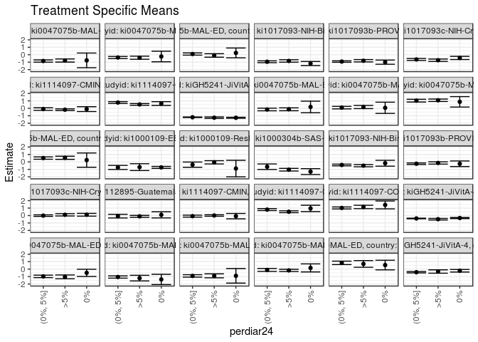

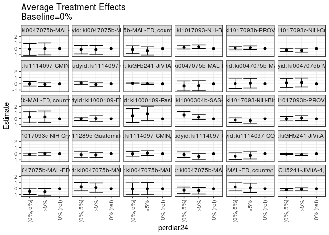

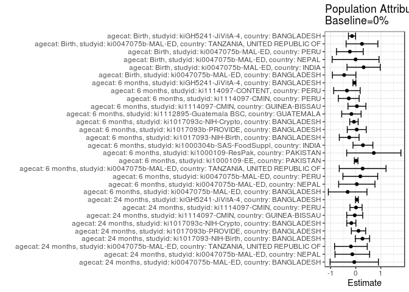

## Results Table

### Parameter: TSM

| agecat | studyid | country | intervention_level | baseline_level | estimate | ci_lower | ci_upper |
| --- | --- | --- | --- | --- | --- | --- | --- |
| Birth | ki0047075b-MAL-ED | BANGLADESH | 0% | NA | -0.5007100 | -0.9850822 | -0.0163379 |
| Birth | ki0047075b-MAL-ED | BANGLADESH | (0%, 5%] | NA | -0.9738204 | -1.1413557 | -0.8062852 |
| Birth | ki0047075b-MAL-ED | BANGLADESH | >5% | NA | -1.0399979 | -1.2948951 | -0.7851008 |
| Birth | ki0047075b-MAL-ED | INDIA | 0% | NA | -1.3837214 | -2.0710227 | -0.6964201 |
| Birth | ki0047075b-MAL-ED | INDIA | (0%, 5%] | NA | -1.0575776 | -1.2123623 | -0.9027929 |
| Birth | ki0047075b-MAL-ED | INDIA | >5% | NA | -1.2060062 | -1.5853208 | -0.8266915 |
| Birth | ki0047075b-MAL-ED | NEPAL | 0% | NA | -0.8981344 | -1.8773692 | 0.0811004 |
| Birth | ki0047075b-MAL-ED | NEPAL | (0%, 5%] | NA | -0.9131635 | -1.0763352 | -0.7499919 |
| Birth | ki0047075b-MAL-ED | NEPAL | >5% | NA | -0.8986696 | -1.1642643 | -0.6330749 |
| Birth | ki0047075b-MAL-ED | PERU | 0% | NA | 0.1613727 | -0.3786285 | 0.7013738 |
| Birth | ki0047075b-MAL-ED | PERU | (0%, 5%] | NA | -0.1076998 | -0.3060436 | 0.0906440 |
| Birth | ki0047075b-MAL-ED | PERU | >5% | NA | -0.1731629 | -0.3248053 | -0.0215205 |
| Birth | ki0047075b-MAL-ED | TANZANIA, UNITED REPUBLIC OF | 0% | NA | 0.5450000 | -0.1026423 | 1.1926423 |
| Birth | ki0047075b-MAL-ED | TANZANIA, UNITED REPUBLIC OF | (0%, 5%] | NA | 0.8427907 | 0.6121065 | 1.0734749 |
| Birth | ki0047075b-MAL-ED | TANZANIA, UNITED REPUBLIC OF | >5% | NA | 0.6983333 | 0.2488389 | 1.1478277 |
| Birth | kiGH5241-JiVitA-4 | BANGLADESH | 0% | NA | -0.2192023 | -0.3906988 | -0.0477059 |
| Birth | kiGH5241-JiVitA-4 | BANGLADESH | (0%, 5%] | NA | -0.4164034 | -0.5093450 | -0.3234618 |
| Birth | kiGH5241-JiVitA-4 | BANGLADESH | >5% | NA | -0.3213767 | -0.5463951 | -0.0963583 |
| 6 months | ki0047075b-MAL-ED | BANGLADESH | 0% | NA | 0.1833333 | -0.5948965 | 0.9615632 |
| 6 months | ki0047075b-MAL-ED | BANGLADESH | (0%, 5%] | NA | -0.1588556 | -0.3343778 | 0.0166665 |
| 6 months | ki0047075b-MAL-ED | BANGLADESH | >5% | NA | -0.1315412 | -0.3244223 | 0.0613399 |
| 6 months | ki0047075b-MAL-ED | NEPAL | 0% | NA | 0.0691161 | -0.6827994 | 0.8210316 |
| 6 months | ki0047075b-MAL-ED | NEPAL | (0%, 5%] | NA | 0.0945968 | -0.0764230 | 0.2656167 |
| 6 months | ki0047075b-MAL-ED | NEPAL | >5% | NA | 0.1696639 | -0.0404809 | 0.3798088 |
| 6 months | ki0047075b-MAL-ED | PERU | 0% | NA | 0.8728571 | 0.1723061 | 1.5734082 |
| 6 months | ki0047075b-MAL-ED | PERU | (0%, 5%] | NA | 1.0287156 | 0.8430187 | 1.2144124 |
| 6 months | ki0047075b-MAL-ED | PERU | >5% | NA | 1.0803185 | 0.9156342 | 1.2450028 |
| 6 months | ki0047075b-MAL-ED | TANZANIA, UNITED REPUBLIC OF | 0% | NA | 0.2427778 | -0.7161220 | 1.2016775 |
| 6 months | ki0047075b-MAL-ED | TANZANIA, UNITED REPUBLIC OF | (0%, 5%] | NA | 0.5185028 | 0.3601992 | 0.6768064 |
| 6 months | ki0047075b-MAL-ED | TANZANIA, UNITED REPUBLIC OF | >5% | NA | 0.5533060 | 0.3421515 | 0.7644605 |

[output cut: 60 more lines]

### Parameter: E(Y)

| agecat | studyid | country | intervention_level | baseline_level | estimate | ci_lower | ci_upper |
| --- | --- | --- | --- | --- | --- | --- | --- |
| Birth | ki0047075b-MAL-ED | BANGLADESH | NA | NA | -0.9630705 | -1.0989132 | -0.8272278 |
| Birth | ki0047075b-MAL-ED | INDIA | NA | NA | -1.0691133 | -1.2078629 | -0.9303637 |
| Birth | ki0047075b-MAL-ED | NEPAL | NA | NA | -0.9044643 | -1.0439568 | -0.7649718 |
| Birth | ki0047075b-MAL-ED | PERU | NA | NA | -0.0735842 | -0.1836203 | 0.0364518 |
| Birth | ki0047075b-MAL-ED | TANZANIA, UNITED REPUBLIC OF | NA | NA | 0.7932203 | 0.5962220 | 0.9902187 |
| Birth | kiGH5241-JiVitA-4 | BANGLADESH | NA | NA | -0.3683163 | -0.4490504 | -0.2875821 |
| 6 months | ki0047075b-MAL-ED | BANGLADESH | NA | NA | -0.1397960 | -0.2688682 | -0.0107238 |
| 6 months | ki0047075b-MAL-ED | NEPAL | NA | NA | 0.1110452 | -0.0202712 | 0.2423616 |
| 6 months | ki0047075b-MAL-ED | PERU | NA | NA | 1.0543956 | 0.9326967 | 1.1760945 |
| 6 months | ki0047075b-MAL-ED | TANZANIA, UNITED REPUBLIC OF | NA | NA | 0.5170513 | 0.3872178 | 0.6468847 |
| 6 months | ki1000109-EE | PAKISTAN | NA | NA | -0.7212766 | -0.8346857 | -0.6078675 |
| 6 months | ki1000109-ResPak | PAKISTAN | NA | NA | -0.1683617 | -0.3528233 | 0.0160999 |
| 6 months | ki1000304b-SAS-FoodSuppl | INDIA | NA | NA | -1.0121579 | -1.1280429 | -0.8962729 |
| 6 months | ki1017093-NIH-Birth | BANGLADESH | NA | NA | -0.4389101 | -0.5279432 | -0.3498771 |
| 6 months | ki1017093b-PROVIDE | BANGLADESH | NA | NA | -0.2083706 | -0.2927992 | -0.1239419 |
| 6 months | ki1017093c-NIH-Crypto | BANGLADESH | NA | NA | 0.0297622 | -0.0491685 | 0.1086930 |
| 6 months | ki1112895-Guatemala BSC | GUATEMALA | NA | NA | -0.0840134 | -0.1945572 | 0.0265305 |
| 6 months | ki1114097-CMIN | GUINEA-BISSAU | NA | NA | -0.0373373 | -0.1163695 | 0.0416948 |
| 6 months | ki1114097-CMIN | PERU | NA | NA | 0.6721017 | 0.5829735 | 0.7612299 |
| 6 months | ki1114097-CONTENT | PERU | NA | NA | 1.0684318 | 0.9515274 | 1.1853362 |
| 6 months | kiGH5241-JiVitA-4 | BANGLADESH | NA | NA | -0.3898055 | -0.4270507 | -0.3525603 |
| 24 months | ki0047075b-MAL-ED | BANGLADESH | NA | NA | -0.8208255 | -0.9429246 | -0.6987264 |
| 24 months | ki0047075b-MAL-ED | NEPAL | NA | NA | -0.3764474 | -0.4898516 | -0.2630431 |
| 24 months | ki0047075b-MAL-ED | TANZANIA, UNITED REPUBLIC OF | NA | NA | 0.0500935 | -0.0748234 | 0.1750103 |
| 24 months | ki1017093-NIH-Birth | BANGLADESH | NA | NA | -0.9115790 | -1.0095022 | -0.8136559 |
| 24 months | ki1017093b-PROVIDE | BANGLADESH | NA | NA | -0.8879412 | -0.9708680 | -0.8050144 |
| 24 months | ki1017093c-NIH-Crypto | BANGLADESH | NA | NA | -0.6103502 | -0.7050157 | -0.5156847 |
| 24 months | ki1114097-CMIN | GUINEA-BISSAU | NA | NA | -0.1445508 | -0.2343737 | -0.0547279 |
| 24 months | ki1114097-CMIN | PERU | NA | NA | 0.6487715 | 0.5686942 | 0.7288488 |
| 24 months | kiGH5241-JiVitA-4 | BANGLADESH | NA | NA | -1.2231088 | -1.2549632 | -1.1912543 |

### Parameter: ATE

| agecat | studyid | country | intervention_level | baseline_level | estimate | ci_lower | ci_upper |
| --- | --- | --- | --- | --- | --- | --- | --- |
| Birth | ki0047075b-MAL-ED | BANGLADESH | 0% | 0% | 0.0000000 | 0.0000000 | 0.0000000 |
| Birth | ki0047075b-MAL-ED | BANGLADESH | (0%, 5%] | 0% | -0.4731104 | -0.9855930 | 0.0393722 |
| Birth | ki0047075b-MAL-ED | BANGLADESH | >5% | 0% | -0.5392879 | -1.0859869 | 0.0074111 |
| Birth | ki0047075b-MAL-ED | INDIA | 0% | 0% | 0.0000000 | 0.0000000 | 0.0000000 |
| Birth | ki0047075b-MAL-ED | INDIA | (0%, 5%] | 0% | 0.3261438 | -0.3788872 | 1.0311747 |
| Birth | ki0047075b-MAL-ED | INDIA | >5% | 0% | 0.1777152 | -0.6085456 | 0.9639760 |
| Birth | ki0047075b-MAL-ED | NEPAL | 0% | 0% | 0.0000000 | 0.0000000 | 0.0000000 |
| Birth | ki0047075b-MAL-ED | NEPAL | (0%, 5%] | 0% | -0.0150291 | -1.0087926 | 0.9787344 |
| Birth | ki0047075b-MAL-ED | NEPAL | >5% | 0% | -0.0005352 | -1.0156060 | 1.0145356 |
| Birth | ki0047075b-MAL-ED | PERU | 0% | 0% | 0.0000000 | 0.0000000 | 0.0000000 |
| Birth | ki0047075b-MAL-ED | PERU | (0%, 5%] | 0% | -0.2690724 | -0.8444046 | 0.3062598 |
| Birth | ki0047075b-MAL-ED | PERU | >5% | 0% | -0.3345356 | -0.8956116 | 0.2265404 |
| Birth | ki0047075b-MAL-ED | TANZANIA, UNITED REPUBLIC OF | 0% | 0% | 0.0000000 | 0.0000000 | 0.0000000 |
| Birth | ki0047075b-MAL-ED | TANZANIA, UNITED REPUBLIC OF | (0%, 5%] | 0% | 0.2977907 | -0.3897089 | 0.9852903 |
| Birth | ki0047075b-MAL-ED | TANZANIA, UNITED REPUBLIC OF | >5% | 0% | 0.1533333 | -0.6350103 | 0.9416770 |
| Birth | kiGH5241-JiVitA-4 | BANGLADESH | 0% | 0% | 0.0000000 | 0.0000000 | 0.0000000 |
| Birth | kiGH5241-JiVitA-4 | BANGLADESH | (0%, 5%] | 0% | -0.1972010 | -0.3855921 | -0.0088100 |
| Birth | kiGH5241-JiVitA-4 | BANGLADESH | >5% | 0% | -0.1021744 | -0.3787859 | 0.1744371 |
| 6 months | ki0047075b-MAL-ED | BANGLADESH | 0% | 0% | 0.0000000 | 0.0000000 | 0.0000000 |
| 6 months | ki0047075b-MAL-ED | BANGLADESH | (0%, 5%] | 0% | -0.3421890 | -1.1399669 | 0.4555890 |
| 6 months | ki0047075b-MAL-ED | BANGLADESH | >5% | 0% | -0.3148746 | -1.1166506 | 0.4869015 |
| 6 months | ki0047075b-MAL-ED | NEPAL | 0% | 0% | 0.0000000 | 0.0000000 | 0.0000000 |
| 6 months | ki0047075b-MAL-ED | NEPAL | (0%, 5%] | 0% | 0.0254808 | -0.7452041 | 0.7961657 |
| 6 months | ki0047075b-MAL-ED | NEPAL | >5% | 0% | 0.1005479 | -0.6801006 | 0.8811964 |
| 6 months | ki0047075b-MAL-ED | PERU | 0% | 0% | 0.0000000 | 0.0000000 | 0.0000000 |
| 6 months | ki0047075b-MAL-ED | PERU | (0%, 5%] | 0% | 0.1558585 | -0.5688864 | 0.8806033 |
| 6 months | ki0047075b-MAL-ED | PERU | >5% | 0% | 0.2074613 | -0.5121863 | 0.9271089 |
| 6 months | ki0047075b-MAL-ED | TANZANIA, UNITED REPUBLIC OF | 0% | 0% | 0.0000000 | 0.0000000 | 0.0000000 |
| 6 months | ki0047075b-MAL-ED | TANZANIA, UNITED REPUBLIC OF | (0%, 5%] | 0% | 0.2757250 | -0.6961539 | 1.2476040 |
| 6 months | ki0047075b-MAL-ED | TANZANIA, UNITED REPUBLIC OF | >5% | 0% | 0.3105282 | -0.6713450 | 1.2924014 |

[output cut: 60 more lines]

### Parameter: PAR

| agecat | studyid | country | intervention_level | baseline_level | estimate | ci_lower | ci_upper |
| --- | --- | --- | --- | --- | --- | --- | --- |
| Birth | ki0047075b-MAL-ED | BANGLADESH | 0% | NA | -0.4623605 | -0.9301179 | 0.0053969 |
| Birth | ki0047075b-MAL-ED | INDIA | 0% | NA | 0.3146081 | -0.3482763 | 0.9774925 |
| Birth | ki0047075b-MAL-ED | NEPAL | 0% | NA | -0.0063299 | -0.9407502 | 0.9280904 |
| Birth | ki0047075b-MAL-ED | PERU | 0% | NA | -0.2349569 | -0.7677767 | 0.2978628 |
| Birth | ki0047075b-MAL-ED | TANZANIA, UNITED REPUBLIC OF | 0% | NA | 0.2482203 | -0.3853218 | 0.8817624 |
| Birth | kiGH5241-JiVitA-4 | BANGLADESH | 0% | NA | -0.1491139 | -0.2910379 | -0.0071899 |
| 6 months | ki0047075b-MAL-ED | BANGLADESH | 0% | NA | -0.3231293 | -1.0925572 | 0.4462985 |
| 6 months | ki0047075b-MAL-ED | NEPAL | 0% | NA | 0.0419291 | -0.6818321 | 0.7656903 |
| 6 months | ki0047075b-MAL-ED | PERU | 0% | NA | 0.1815385 | -0.5115810 | 0.8746579 |
| 6 months | ki0047075b-MAL-ED | TANZANIA, UNITED REPUBLIC OF | 0% | NA | 0.2742735 | -0.6581096 | 1.2066566 |
| 6 months | ki1000109-EE | PAKISTAN | 0% | NA | 0.0149852 | -0.0573139 | 0.0872844 |
| 6 months | ki1000109-ResPak | PAKISTAN | 0% | NA | 0.7199353 | -0.3609937 | 1.8008644 |
| 6 months | ki1000304b-SAS-FoodSuppl | INDIA | 0% | NA | 0.2862473 | -0.1093656 | 0.6818602 |
| 6 months | ki1017093-NIH-Birth | BANGLADESH | 0% | NA | -0.2615273 | -0.6561573 | 0.1331027 |
| 6 months | ki1017093b-PROVIDE | BANGLADESH | 0% | NA | 0.0393326 | -0.3385680 | 0.4172331 |
| 6 months | ki1017093c-NIH-Crypto | BANGLADESH | 0% | NA | -0.0725388 | -0.2406997 | 0.0956221 |
| 6 months | ki1112895-Guatemala BSC | GUATEMALA | 0% | NA | -0.1733221 | -0.5598941 | 0.2132499 |
| 6 months | ki1114097-CMIN | GUINEA-BISSAU | 0% | NA | 0.0469522 | -0.3101692 | 0.4040736 |
| 6 months | ki1114097-CMIN | PERU | 0% | NA | -0.2790274 | -0.6934905 | 0.1354357 |
| 6 months | ki1114097-CONTENT | PERU | 0% | NA | -0.3513182 | -0.8794617 | 0.1768252 |
| 6 months | kiGH5241-JiVitA-4 | BANGLADESH | 0% | NA | -0.0536223 | -0.1124433 | 0.0051987 |
| 24 months | ki0047075b-MAL-ED | BANGLADESH | 0% | NA | -0.0599921 | -1.0242302 | 0.9042459 |
| 24 months | ki0047075b-MAL-ED | NEPAL | 0% | NA | -0.1368474 | -0.8271284 | 0.5534336 |
| 24 months | ki0047075b-MAL-ED | TANZANIA, UNITED REPUBLIC OF | 0% | NA | -0.1932399 | -0.8445684 | 0.4580887 |
| 24 months | ki1017093-NIH-Birth | BANGLADESH | 0% | NA | 0.2684210 | -0.0167391 | 0.5535810 |
| 24 months | ki1017093b-PROVIDE | BANGLADESH | 0% | NA | 0.1098366 | -0.1753178 | 0.3949910 |
| 24 months | ki1017093c-NIH-Crypto | BANGLADESH | 0% | NA | -0.1756605 | -0.3568602 | 0.0055391 |
| 24 months | ki1114097-CMIN | GUINEA-BISSAU | 0% | NA | -0.0408787 | -0.3590707 | 0.2773134 |
| 24 months | ki1114097-CMIN | PERU | 0% | NA | 0.0112567 | -0.2315238 | 0.2540372 |
| 24 months | kiGH5241-JiVitA-4 | BANGLADESH | 0% | NA | 0.0454883 | -0.0098720 | 0.1008487 |